# Bruno_Diego_UFF

- Autores: Diego Dias.
- Autores: Bruno de Sá.
- Professor: Marcos Lages.
- Disciplina: Visualização de Dados.
- Faculdade: Universidade Federal Fluminense.
- Curso
- Objetivo.
  - Análise dos impactos econômicos mundiais causados pela COVID- 19 e identificação dos setores mais afetados.

# 1- Sumário

- 1- Importando as bibliotecas.
- 2 - Carregando os dados.
- 3 - Analisando os dados.
- 4- Visualizandos os dados.
- 5 - Apredizagem de Máquina
- 6 -Conclusão
- 7 Referências.

# 1 - Importando as bibliotecas.

```python
# Manipulação de dados
import numpy as np
import pandas as pd
import random as rnd
from beakerx import *
#Visualização de dados
import seaborn as sns
import matplotlib.pyplot as plt
import matplotlib.cbook as cbook
# Visualização de dados de modo Interativo
from plotly.graph_objs import *
import plotly.offline as py
import plotly.graph_objs as go
import plotly.graph_objects as go
import plotly.express as px


#Aprendizagem de máquina(Machine Learning)
from sklearn.neighbors import KNeighborsClassifier
from sklearn.model_selection import cross_val_score
from sklearn.model_selection import train_test_split
from sklearn.linear_model import LinearRegression
from sklearn.metrics import r2_score,mean_squared_error
```

# 2 - Carregando os dados.

```python
df_economia = pd.read_csv('economia.csv')
df_train = pd.read_csv('train_covid.csv')
```

# 3 - Analisando os dados.

```python
#selecionando os cinco primeira linhas
from beakerx import *
pd.read_csv("economia.csv")
```

|  | Economy | ADB Country Code | Sector | Country | Scenario | as % of total GDP | Money | Employment | sectorGDP | sectoremployment |
| --- | --- | --- | --- | --- | --- | --- | --- | --- | --- | --- |
| 0 | Australia | AUS | Agriculture, Mining and Quarrying | 1.433904e+09 | Shorter containment, smaller demand shock | -0.33 | 4,671.70 | 18 | -2.70 | -2.65 |
| 1 | Australia | AUS | Business, Trade, Personal, and Public Services | 1.433904e+09 | Shorter containment, smaller demand shock | -1.41 | 20,147.01 | 191 | -2.31 | -2.29 |
| 2 | Australia | AUS | Hotel and restaurants and Other Personal Services | 1.433904e+09 | Shorter containment, smaller demand shock | -0.35 | 5,023.10 | 112 | -6.70 | -7.24 |
| 3 | Australia | AUS | Light/Heavy Manufacturing, Utilities, and Cons... | 1.433904e+09 | Shorter containment, smaller demand shock | -0.39 | 5,660.89 | 54 | -2.31 | -2.29 |
| 4 | Australia | AUS | Transport services | 1.433904e+09 | Shorter containment, smaller demand shock | -0.30 | 4,307.48 | 47 | -6.47 | -7.22 |
| ... | ... | ... | ... | ... | ... | ... | ... | ... | ... | ... |
| 1571 | Bhutan | BHU | Longer containment, larger demand shock | 2.534965e+03 | Additional impact under Longer containment, la... | -0.79 | 19.96 | na | -0.79 | na |
| 1572 | Kyrgyz Republic | KGZ | Longer containment, larger demand shock | 8.092837e+03 | Additional impact under Longer containment, la... | -2.19 | 176.98 | na | -2.19 | na |
| 1573 | Cambodia | CAM | Longer containment, larger demand shock | 2.454247e+04 | Additional impact under Longer containment, la... | -7.43 | 1,822.32 | na | -7.43 | na |
| 1574 | Singapore | SIN | Longer containment, larger demand shock | 3.641567e+05 | Additional impact under Longer containment, la... | -2.61 | 9,513.96 | na | -2.61 | na |
| 1575 | Hong Kong, China | HKG | Longer containment, larger demand shock | 3.626820e+05 | Additional impact under Longer containment, la... | -2.74 | 9,930.77 | na | -2.74 | na |

1576 rows × 10 columns

```python
# obtendo quantidade, média, desvio padrão, valor mínimo, valor máximo porcentagem das coluna "Country 2018 GDP"
df_economia.describe()
```

|  | Country |
| --- | --- |
| count | 1.576000e+03 |
| mean | 3.557850e+08 |
| std | 8.518034e+08 |
| min | 2.534965e+03 |
| 25% | 6.097170e+04 |
| 50% | 3.556753e+05 |
| 75% | 2.083864e+06 |
| max | 3.947620e+09 |

```python
# obtendo informação da base de  dados.
df_economia.info()
```

```
<class 'pandas.core.frame.DataFrame'>
RangeIndex: 1576 entries, 0 to 1575
Data columns (total 10 columns):
 #   Column             Non-Null Count  Dtype
---  ------             --------------  -----
 0   Economy            1576 non-null   object
 1   ADB Country Code   1576 non-null   object
 2   Sector             1576 non-null   object
 3   Country            1576 non-null   float64
 4   Scenario           1576 non-null   object
 5   as % of total GDP  1576 non-null   object
 6   Money              1576 non-null   object
 7   Employment         1576 non-null   object
 8   sectorGDP          1576 non-null   object
 9   sectoremployment   1576 non-null   object
dtypes: float64(1), object(9)
memory usage: 123.2+ KB
```

```python
# indexação  do dataframe
df_economia.index
```

```
RangeIndex(start=0, stop=1576, step=1)
```

```python
# definição da coluna com indice
df_economia.set_index('Employment', inplace= True)
df_economia.head()
```

| Employment | Economy | ADB Country Code | Sector | Country | Scenario | as % of total GDP | Money | sectorGDP | sectoremployment |
| --- | --- | --- | --- | --- | --- | --- | --- | --- | --- |
| 18 | Australia | AUS | Agriculture, Mining and Quarrying | 1.433904e+09 | Shorter containment, smaller demand shock | -0.33 | 4,671.70 | -2.70 | -2.65 |
| 191 | Australia | AUS | Business, Trade, Personal, and Public Services | 1.433904e+09 | Shorter containment, smaller demand shock | -1.41 | 20,147.01 | -2.31 | -2.29 |
| 112 | Australia | AUS | Hotel and restaurants and Other Personal Services | 1.433904e+09 | Shorter containment, smaller demand shock | -0.35 | 5,023.10 | -6.70 | -7.24 |
| 54 | Australia | AUS | Light/Heavy Manufacturing, Utilities, and Cons... | 1.433904e+09 | Shorter containment, smaller demand shock | -0.39 | 5,660.89 | -2.31 | -2.29 |
| 47 | Australia | AUS | Transport services | 1.433904e+09 | Shorter containment, smaller demand shock | -0.30 | 4,307.48 | -6.47 | -7.22 |

```python
# verificando as colunas e seus valo|res
df_economia.columns
```

```
Index(['Economy', 'ADB Country Code', 'Sector', 'Country', 'Scenario',
       'as % of total GDP', 'Money', 'sectorGDP', 'sectoremployment'],
      dtype='object')
```

```python
# valores
df_economia.values
```

```
array([['Australia', 'AUS', 'Agriculture, Mining and Quarrying', ...,
        ' 4,671.70 ', '-2.70', '-2.65'],
       ['Australia', 'AUS',
        'Business, Trade, Personal, and Public Services', ...,
        ' 20,147.01 ', '-2.31', '-2.29'],
       ['Australia', 'AUS',
        'Hotel and restaurants and Other Personal Services', ...,
        ' 5,023.10 ', '-6.70', '-7.24'],
       ...,
       ['Cambodia', 'CAM', 'Longer containment, larger demand shock',
        ..., ' 1,822.32 ', '-7.43', 'na'],
       ['Singapore', 'SIN', 'Longer containment, larger demand shock',
        ..., ' 9,513.96 ', '-2.61', 'na'],
       ['Hong Kong, China', 'HKG',
        'Longer containment, larger demand shock', ..., ' 9,930.77 ',
        '-2.74', 'na']], dtype=object)
```

# 4- Aprendizagem de Máquina.

- Convertendo os dados em "String" em dados "númericos".

```python
from sklearn import preprocessing
def encode_features(df_train, df_test):
    features = ['Economy', 'ADB Country Code', 'Sector', 'Country', 'Scenario','as % of total GDP',]
    df_combined = pd.concat([df_train[features], df_test[features]])

    for feature in features:
        le = preprocessing.LabelEncoder()
        le = le.fit(df_combined[feature])
        df_train[feature] = le.transform(df_train[feature])
        df_test[feature] = le.transform(df_test[feature])
    return df_train, df_test

df_train, df = encode_features(df_train, df_economia)
df_train.head(5)
```

|  | Economy | ADB Country Code | Sector | Country | Scenario | as % of total GDP | Money | Employment | sectorGDP | sectoremployment |
| --- | --- | --- | --- | --- | --- | --- | --- | --- | --- | --- |
| 0 | 0 | 0 | 0 | 53 | 3 | 32 | 4,671.70 | 18 | -2.70 | -2.65 |
| 1 | 0 | 0 | 1 | 53 | 3 | 132 | 20,147.01 | 191 | -2.31 | -2.29 |
| 2 | 0 | 0 | 2 | 53 | 3 | 34 | 5,023.10 | 112 | -6.70 | -7.24 |
| 3 | 0 | 0 | 3 | 53 | 3 | 38 | 5,660.89 | 54 | -2.31 | -2.29 |
| 4 | 0 | 0 | 6 | 53 | 3 | 29 | 4,307.48 | 47 | -6.47 | -7.22 |

- Buscando o melhor modelo utilizando somente coluna(variável).
- Selecionando a coluna "Sector".

```python
X = df_train.Sector
Y =df_train.Scenario
```

- Convertendo em matriz(2D)

```python
X=np.array(X).reshape(-1,1)
Y=np.array(Y).reshape(-1,1)
```

- Dividindo em conjunto de dados Treinamento e Teste

```python
X_train,X_test,Y_train,Y_test = train_test_split(X,Y,random_state=101)
model1 = LinearRegression()
model1.fit(X_train,Y_train)
```

```
LinearRegression()
```

- Prevendo o valor de Y

```python
Y_pred = model1.predict(X_test)
```

- Métrica de avaliação para verificar a proximidade do valor previsto

```python
previsto =r2_score(Y_test,Y_pred)
previsto
```

```
0.0013627448087882854
```

# 5 Visualização Dados Estática

### 5.0 -Plotagem Verificar valores nulos na tabela

```
 O seguinte gráfico tem como objetivo verificar percentual de valores nulos na tabela.
```

[figure not shown]

```python
# verificando extência de  valores nulos nas tabelas
sns.heatmap(df_economia.isnull())
```

### 5.1 -Plotagem de distribuições univariadas

```
 O gráfico de distribuições univariadas tem como objetivo te visão geral da estimativa daquela tabela.
```

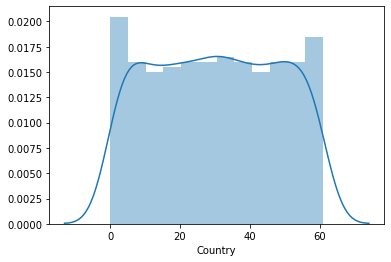

```python
# Plotagem de distribuições univariadas

sns.distplot(df_economia['Country'])
```

### 5.2 Plotagem de distribuições bivariadas

A distribuições bivariadas útil para visualizar de duas variáveis. A forma mais fácil de o fazer é utlizando o seabornar com apenas a função jointplot(), que cria uma figura multi-panel que mostra tanto a relação bivariada (ou conjunta) entre duas variáveis juntamente com a distribuição univariada (ou marginal) de cada uma em eixos separados.

### 5.3 Plotagem de Scatterplot

O gráfico de dispersão é forma de visualizar uma distribuição bivariada, onde cada observação é mostrada com o ponto nos valores x e y. Isto é analgésico para uma parcela de tapete em duas dimensões. Pode-se desenhar um gráfico de dispersão com a função matplotlib plt.scatter, e é também o tipo padrão de gráfico mostrado pela função jointplot():

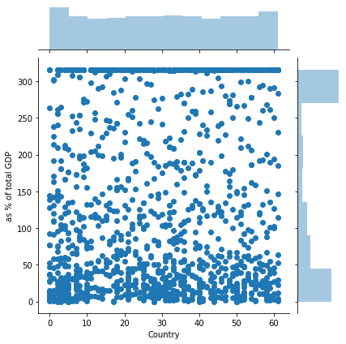

```python
sns.jointplot(df_train['Country'], df_train['as % of total GDP'])
```

### 5.4 Plotagem do gráfico( 'Hex Bin Plots')

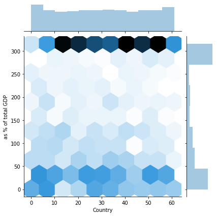

```python
sns.jointplot(df_train['Country'], df_train['as % of total GDP'], kind="hex")
```